# Assignment#6

#### #3. 계산 시간을 줄이기 위해서 첫 5,000개의 데이터만 training set으로 사용하고, 나머지 모든 데이터를 test set으로 사용한다. Training set을 사용하여 predictive model을 만들어보자.

##### 3-1) 지금까지 학습한 모델을 최대한 활용해보고, 분석 과정과 결과를 report하자. 사용하는 모델, 모델에 포함되는 파라미터에 대한 튜닝, 모델에 포함되는 feature의 수, DTM/TF-IDF 사용 여부 등이 classification accuracy에 영향을 미칠 수 있다.

```r
#필요한 패키지 업로드
library(rsample)
library(randomForest)
library(nnet)
library(caret)
library(vip)
library(e1071)
#processing이 끝난 DTM2을 데이터프레임으로 변환하자.
dtm_df <- data.frame(as.matrix(dtm2))
str(dtm_df)
```

```
## 'data.frame':    14640 obs. of  330 variables:
##  $ X.jetblu         : num  0 0 0 0 0 0 0 0 0 0 ...
##  $ abl              : num  0 0 0 0 0 0 0 0 0 0 ...
##  $ account          : num  0 0 0 0 0 0 0 0 0 0 ...
##  $ actual           : num  0 0 0 0 0 0 0 0 0 0 ...
##  $ add              : num  0 0 0 0 0 0 0 0 0 0 ...
##  $ agent            : num  0 0 0 0 0 0 0 0 0 0 ...
##  $ ago              : num  0 0 0 0 0 0 0 0 0 0 ...
##  $ air              : num  0 0 0 0 0 0 0 0 0 0 ...
##  $ airlin           : num  0 0 0 0 0 0 0 0 0 0 ...
##  $ airport          : num  0 0 0 0 0 0 0 0 0 0 ...
##  $ airway           : num  0 0 0 0 0 0 0 0 0 0 ...
##  $ allow            : num  0 0 0 0 0 0 0 0 0 0 ...
##  $ almost           : num  0 0 0 0 0 0 0 0 0 0 ...
##  $ alreadi          : num  0 0 0 0 0 0 0 0 0 0 ...
```

[output cut: 86 more lines]

```r
#마찬가지로 tf_idf2도 데이터프레임으로 변환하자.
tf_idf_df <- data.frame(as.matrix(tf_idf2))
str(tf_idf_df)
```

```
## 'data.frame':    14640 obs. of  330 variables:
##  $ X.jetblu         : num  0 0 0 0 0 0 0 0 0 0 ...
##  $ abl              : num  0 0 0 0 0 0 0 0 0 0 ...
##  $ account          : num  0 0 0 0 0 0 0 0 0 0 ...
##  $ actual           : num  0 0 0 0 0 0 0 0 0 0 ...
##  $ add              : num  0 0 0 0 0 0 0 0 0 0 ...
##  $ agent            : num  0 0 0 0 0 0 0 0 0 0 ...
##  $ ago              : num  0 0 0 0 0 0 0 0 0 0 ...
##  $ air              : num  0 0 0 0 0 0 0 0 0 0 ...
##  $ airlin           : num  0 0 0 0 0 0 0 0 0 0 ...
##  $ airport          : num  0 0 0 0 0 0 0 0 0 0 ...
##  $ airway           : num  0 0 0 0 0 0 0 0 0 0 ...
##  $ allow            : num  0 0 0 0 0 0 0 0 0 0 ...
##  $ almost           : num  0 0 0 0 0 0 0 0 0 0 ...
##  $ alreadi          : num  0 0 0 0 0 0 0 0 0 0 ...
```

[output cut: 86 more lines]

```r
#feature의 이름을 적당한 형태로 조정해주고, target변수를 추가하자.
colnames(dtm_df) <- make.names(colnames(dtm_df))
dtm_df$sentiment <- df$sentiment
str(dtm_df)
```

```
## 'data.frame':    14640 obs. of  331 variables:
##  $ X.jetblu         : num  0 0 0 0 0 0 0 0 0 0 ...
##  $ abl              : num  0 0 0 0 0 0 0 0 0 0 ...
##  $ account          : num  0 0 0 0 0 0 0 0 0 0 ...
##  $ actual           : num  0 0 0 0 0 0 0 0 0 0 ...
##  $ add              : num  0 0 0 0 0 0 0 0 0 0 ...
##  $ agent            : num  0 0 0 0 0 0 0 0 0 0 ...
##  $ ago              : num  0 0 0 0 0 0 0 0 0 0 ...
##  $ air              : num  0 0 0 0 0 0 0 0 0 0 ...
##  $ airlin           : num  0 0 0 0 0 0 0 0 0 0 ...
##  $ airport          : num  0 0 0 0 0 0 0 0 0 0 ...
##  $ airway           : num  0 0 0 0 0 0 0 0 0 0 ...
##  $ allow            : num  0 0 0 0 0 0 0 0 0 0 ...
##  $ almost           : num  0 0 0 0 0 0 0 0 0 0 ...
##  $ alreadi          : num  0 0 0 0 0 0 0 0 0 0 ...
```

[output cut: 86 more lines]

```r
colnames(tf_idf_df) <- make.names(colnames(tf_idf_df))
tf_idf_df$sentiment <- df$sentiment
str(tf_idf_df)
```

```
## 'data.frame':    14640 obs. of  331 variables:
##  $ X.jetblu         : num  0 0 0 0 0 0 0 0 0 0 ...
##  $ abl              : num  0 0 0 0 0 0 0 0 0 0 ...
##  $ account          : num  0 0 0 0 0 0 0 0 0 0 ...
##  $ actual           : num  0 0 0 0 0 0 0 0 0 0 ...
##  $ add              : num  0 0 0 0 0 0 0 0 0 0 ...
##  $ agent            : num  0 0 0 0 0 0 0 0 0 0 ...
##  $ ago              : num  0 0 0 0 0 0 0 0 0 0 ...
##  $ air              : num  0 0 0 0 0 0 0 0 0 0 ...
##  $ airlin           : num  0 0 0 0 0 0 0 0 0 0 ...
##  $ airport          : num  0 0 0 0 0 0 0 0 0 0 ...
##  $ airway           : num  0 0 0 0 0 0 0 0 0 0 ...
##  $ allow            : num  0 0 0 0 0 0 0 0 0 0 ...
##  $ almost           : num  0 0 0 0 0 0 0 0 0 0 ...
##  $ alreadi          : num  0 0 0 0 0 0 0 0 0 0 ...
```

[output cut: 86 more lines]

```r
# Data Splitting=====================================================
#이번 과제에서는 계산시간을 줄이기 위해 첫 5000개 데이터만 사용
# Train set과 Test set으로 분할하자.
TrainD <- dtm_df[1:5000,]
TestD <- dtm_df[-c(1:5000),]

TrainI <- tf_idf_df[1:5000,]
TestI <- tf_idf_df[-c(1:5000),]

#initial_split 사용해 비슷한 비율로 validation set을 만들어주자.
set.seed(123)
split <- initial_split(TrainD, prop =0.8, strata = "sentiment")
trainD <- training(split)
testD <- testing(split)

set.seed(123)
Split <- initial_split(TrainI, prop =0.8, strata = "sentiment")
trainI<- training(Split)
testI <- testing(Split)


#비슷하게 배분된 것을 확인할 수 있다.
table(trainD$sentiment)
```

```
##
## negative  neutral positive
##     2505      846      651
```

```r
table(testD$sentiment)
```

```
##
## negative  neutral positive
##      625      211      162
```

```r
table(trainI$sentiment)
```

```
##
## negative  neutral positive
##     2505      846      651
```

```r
table(testI$sentiment)
```

```
##
## negative  neutral positive
##      625      211      162
```

```r
#Multi-class Classification=====================================================================
#e1071 패키지의 svm() 함수는 multi class classification 문제를 one-versus-one classificationd으로 적용한다.

#cost와 gamma 파라미터는 10^x이나 2^x 단위로 tuning을 시도해보는 것이 바람직하다.
set.seed(123)
tune.out <- tune(svm, sentiment~., data=trainD, kernel="radial",
                 ranges=list(cost=c(0.01, 0.1, 1, 10, 100),
                             gamma=c(0.01, 0.1, 1, 10, 100)))
```

[output not shown]

[output cut: 697 more lines]

[output not shown]

```r
summary(tune.out)
```

```
##
## Parameter tuning of 'svm':
##
## - sampling method: 10-fold cross validation
##
## - best parameters:
##  cost gamma
##    10  0.01
##
## - best performance: 0.2743653
##
## - Detailed performance results:
##     cost gamma     error dispersion
## 1  1e-02 1e-02 0.3740630 0.01619896
## 2  1e-01 1e-02 0.3740630 0.01619896
## 3  1e+00 1e-02 0.3358342 0.01048787
## 4  1e+01 1e-02 0.2743653 0.01809783
## 5  1e+02 1e-02 0.2748635 0.02233681
## 6  1e-02 1e-01 0.3740630 0.01619896
## 7  1e-01 1e-01 0.3300867 0.01049035
## 8  1e+00 1e-01 0.2748660 0.01684845
## 9  1e+01 1e-01 0.2788641 0.01693506
## 10 1e+02 1e-01 0.3030973 0.02091457
## 11 1e-02 1e+00 0.3740630 0.01619896
## 12 1e-01 1e+00 0.3588211 0.01721364
## 13 1e+00 1e+00 0.3275948 0.01924311
## 14 1e+01 1e+00 0.3235948 0.01923541
## 15 1e+02 1e+00 0.3238448 0.01905448
## 16 1e-02 1e+01 0.3740630 0.01619896
## 17 1e-01 1e+01 0.3635686 0.01696991
## 18 1e+00 1e+01 0.3435810 0.01835575
## 19 1e+01 1e+01 0.3435810 0.01835575
## 20 1e+02 1e+01 0.3435810 0.01835575
## 21 1e-02 1e+02 0.3740630 0.01619896
## 22 1e-01 1e+02 0.3635686 0.01696991
## 23 1e+00 1e+02 0.3435810 0.01835575
## 24 1e+01 1e+02 0.3435810 0.01835575
## 25 1e+02 1e+02 0.3435810 0.01835575
```

```r
#test set(valid set)에 대한 class 예측 후 confusion matrix 계산
pred_svm <- predict(tune.out$best.model, newdata=testD)
confusionMatrix(pred_svm, testD$sentiment)
```

```
## Confusion Matrix and Statistics
##
##           Reference
## Prediction negative neutral positive
##   negative      580     107       48
##   neutral        29      81       26
##   positive       16      23       88
##
## Overall Statistics
##
##                Accuracy : 0.7505
##                  95% CI : (0.7224, 0.7771)
##     No Information Rate : 0.6263
##     P-Value [Acc > NIR] : < 2.2e-16
##
##                   Kappa : 0.4901
##
##  Mcnemar's Test P-Value : 3.74e-13
##
## Statistics by Class:
##
##                      Class: negative Class: neutral Class: positive
## Sensitivity                   0.9280        0.38389         0.54321
## Specificity                   0.5845        0.93011         0.95335
## Pos Pred Value                0.7891        0.59559         0.69291
## Neg Pred Value                0.8289        0.84919         0.91504
## Prevalence                    0.6263        0.21142         0.16232
## Detection Rate                0.5812        0.08116         0.08818
## Detection Prevalence          0.7365        0.13627         0.12725
## Balanced Accuracy             0.7562        0.65700         0.74828
```

```r
#____________________________________________________________________
#Multi-class Classification TF-IDF로 위와 동일한 과정을 수행한다.


#cost와 gamma 파라미터는 10^x이나 2^x 단위로 tuning을 시도해보는 것이 바람직하다.
set.seed(123)
tune.out1 <- tune(svm, sentiment~., data=trainI, kernel="radial",
                 ranges=list(cost=c(0.01, 0.1, 1, 10, 100, 100),
                             gamma=c(0.01, 0.1, 1, 10, 100)))
```

[output not shown]

[output cut: 847 more lines]

[output not shown]

```r
summary(tune.out1)
```

```
##
## Parameter tuning of 'svm':
##
## - sampling method: 10-fold cross validation
##
## - best parameters:
##  cost gamma
##    10   0.1
##
## - best performance: 0.2711135
##
## - Detailed performance results:
##     cost gamma     error dispersion
## 1  1e-02 1e-02 0.3740630 0.01619896
## 2  1e-01 1e-02 0.3740630 0.01619896
```

[output cut: 28 more lines]

```r
#test set(valid set)에 대한 class 예측 후 confusion matrix 계산
pred_svm1 <- predict(tune.out1$best.model, newdata=testI)
confusionMatrix(pred_svm1, testI$sentiment)
```

```
## Confusion Matrix and Statistics
##
##           Reference
## Prediction negative neutral positive
##   negative      557     102       53
##   neutral        53      91       25
##   positive       15      18       84
##
## Overall Statistics
##
##                Accuracy : 0.7335
##                  95% CI : (0.7049, 0.7607)
##     No Information Rate : 0.6263
##     P-Value [Acc > NIR] : 4.736e-13
##
##                   Kappa : 0.4652
##
##  Mcnemar's Test P-Value : 3.019e-08
##
## Statistics by Class:
##
##                      Class: negative Class: neutral Class: positive
## Sensitivity                   0.8912        0.43128         0.51852
## Specificity                   0.5845        0.90089         0.96053
## Pos Pred Value                0.7823        0.53846         0.71795
## Neg Pred Value                0.7622        0.85525         0.91146
## Prevalence                    0.6263        0.21142         0.16232
## Detection Rate                0.5581        0.09118         0.08417
## Detection Prevalence          0.7134        0.16934         0.11723
## Balanced Accuracy             0.7378        0.66608         0.73952
```

```r
#Bagging=============================================================
#random Forest_bagging model- DTF

#trainset에 bagging 적용(mtry=p로 설정하면 bagging을 적용하는 것과 같다.)
set.seed(123)
bag <- randomForest(sentiment~. , data= trainD, ntree=300, mtry=331)
bag
```

```
##
## Call:
##  randomForest(formula = sentiment ~ ., data = trainD, ntree = 300,      mtry = 331)
##                Type of random forest: classification
##                      Number of trees: 300
## No. of variables tried at each split: 330
##
##         OOB estimate of  error rate: 30.91%
## Confusion matrix:
##          negative neutral positive class.error
## negative     2089     274      142   0.1660679
## neutral       406     336      104   0.6028369
## positive      193     118      340   0.4777266
```

```r
#bagging model의 out-of bag prediction과 error rate
head(bag$predicted)
```

```
##        1        2        3        4        5        6
##  neutral  neutral positive  neutral  neutral negative
## Levels: negative neutral positive
```

```r
head(bag$err.rate)
```

```
##            OOB  negative   neutral  positive
## [1,] 0.3915063 0.2834225 0.6371951 0.4754098
## [2,] 0.3800000 0.2726662 0.5930902 0.5051282
## [3,] 0.3781709 0.2602151 0.6136012 0.5153374
## [4,] 0.3690476 0.2448687 0.6099585 0.5276753
## [5,] 0.3603228 0.2359202 0.6068152 0.5208333
## [6,] 0.3566452 0.2327071 0.6005089 0.5198675
```

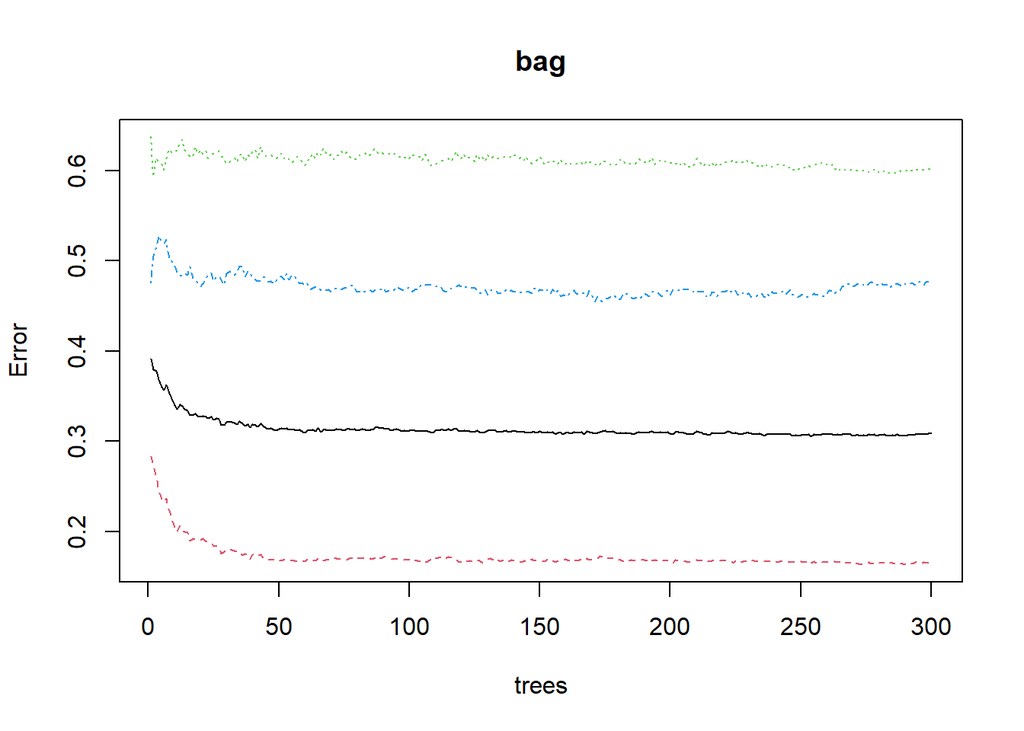

```r
#시각화
plot(bag)
```

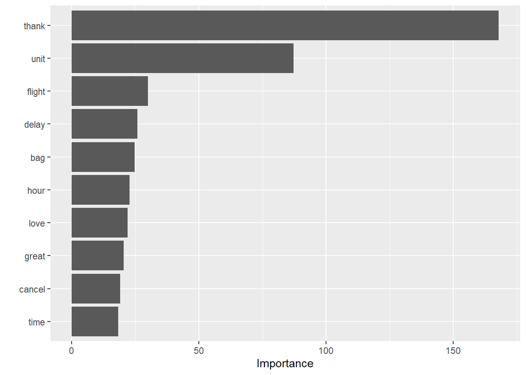

```r
#feature들의 중요도를 확인해보자
vip(bag)
```

```r
bag$importance
```

```
##                   MeanDecreaseGini
## X.jetblu                 0.0000000
## abl                      2.1739061
## account                  2.2992616
## actual                   5.5499506
## add                      5.6908544
## agent                    5.2596322
## ago                      1.7337173
## air                      4.1927267
## airlin                  14.7184285
## airport                  7.1945186
## airway                   1.6832732
## allow                    4.8205304
## almost                   1.7379916
## alreadi                  4.4862065
## also                     2.8685443
## alway                    4.5396850
## amaz                    15.8362632
## american                 0.1407739
## americanair              2.4521119
## amp                      8.6418741
## anoth                    5.0005731
## answer                   1.4696932
## anyon                    1.8984870
## anyth                    2.9307400
## apolog                   1.2574031
## app                      4.9576173
## appreci                  7.6958260
## arriv                    3.9746473
## ask                      5.4712747
## assist                   3.4200165
## attend                   6.0427603
## avail                    3.9385104
## away                     2.8670877
## awesom                  11.7363121
## back                     9.9183438
## bad                      4.0670553
## bag                     24.6940650
## baggag                   7.5621998
## best                     9.1397125
```

[output cut: 276 more lines]

```
## weather                  3.8612419
## websit                   9.9363413
## week                     5.9108098
## well                     6.0641384
## wife                     1.6623041
## wifi                     7.7671407
## will                    12.5046388
## without                  1.9296935
## work                    10.9468782
## worst                    8.4740312
## wrong                    2.2852670
## year                     6.3853921
## yes                      9.7290271
## yesterday                4.8583366
## yet                      1.9869454
```

```r
#bagging 모델의 test(valid) set에 대한 class 예측
pred_bag <- predict(bag, newdata = testD, type="class")
#위 결과를 confusionMatrix로 확인
confusionMatrix(factor(pred_bag),testD$sentiment)
```

```
## Confusion Matrix and Statistics
##
##           Reference
## Prediction negative neutral positive
##   negative      524      96       50
##   neutral        73      90       17
##   positive       28      25       95
##
## Overall Statistics
##
##                Accuracy : 0.7104
##                  95% CI : (0.6812, 0.7384)
##     No Information Rate : 0.6263
##     P-Value [Acc > NIR] : 1.344e-08
##
##                   Kappa : 0.4403
##
##  Mcnemar's Test P-Value : 0.01251
##
## Statistics by Class:
##
##                      Class: negative Class: neutral Class: positive
## Sensitivity                   0.8384        0.42654         0.58642
## Specificity                   0.6086        0.88564         0.93660
## Pos Pred Value                0.7821        0.50000         0.64189
## Neg Pred Value                0.6921        0.85208         0.92118
## Prevalence                    0.6263        0.21142         0.16232
## Detection Rate                0.5251        0.09018         0.09519
## Detection Prevalence          0.6713        0.18036         0.14830
## Balanced Accuracy             0.7235        0.65609         0.76151
```

```r
#____________________________________________________________________
#random Forest_bagging model- TF-IDF로 위와 동일한 과정을 수행한다

set.seed(123)
bag1 <- randomForest(sentiment~. , data= trainI, ntree=300, mtry=331)
bag1
```

```
##
## Call:
##  randomForest(formula = sentiment ~ ., data = trainI, ntree = 300,      mtry = 331)
##                Type of random forest: classification
##                      Number of trees: 300
## No. of variables tried at each split: 330
##
##         OOB estimate of  error rate: 32.61%
## Confusion matrix:
##          negative neutral positive class.error
## negative     2118     260      127   0.1544910
## neutral       474     275       97   0.6749409
## positive      232     115      304   0.5330261
```

```r
#bagging model의 out-of bag prediction과 error rate
head(bag1$predicted)
```

```
##        1        2        3        4        5        6
##  neutral  neutral  neutral positive  neutral positive
## Levels: negative neutral positive
```

```r
head(bag1$err.rate)
```

```
##            OOB  negative   neutral  positive
## [1,] 0.3715992 0.2299465 0.6310976 0.5655738
## [2,] 0.3732777 0.2277966 0.6472795 0.5503876
## [3,] 0.3728188 0.2340885 0.6333853 0.5587629
## [4,] 0.3818020 0.2346502 0.6513889 0.5940959
## [5,] 0.3739612 0.2269316 0.6736842 0.5538462
## [6,] 0.3689655 0.2169492 0.6766917 0.5539216
```

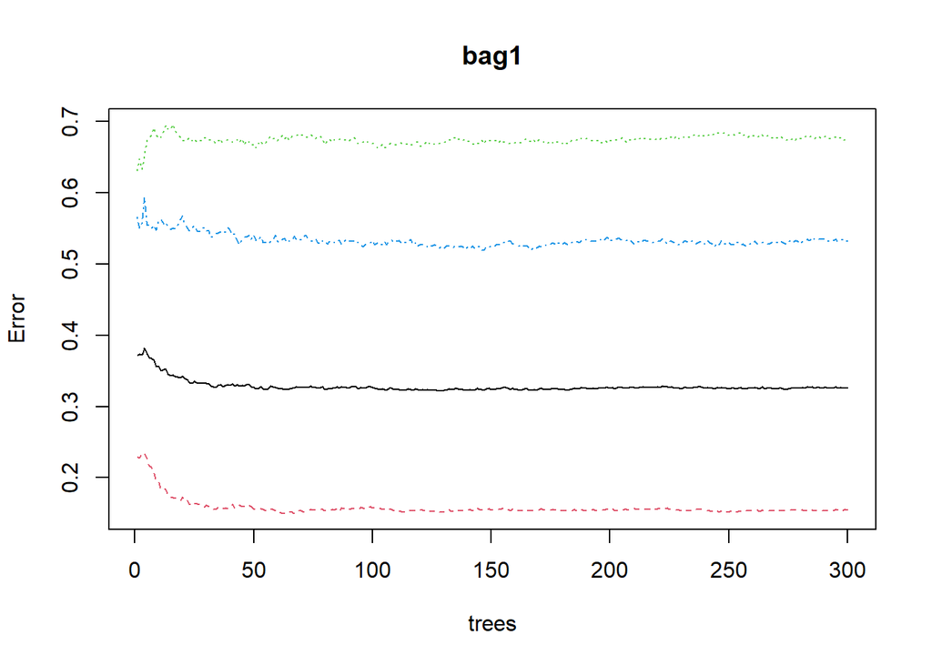

```r
#시각화
plot(bag1)
```

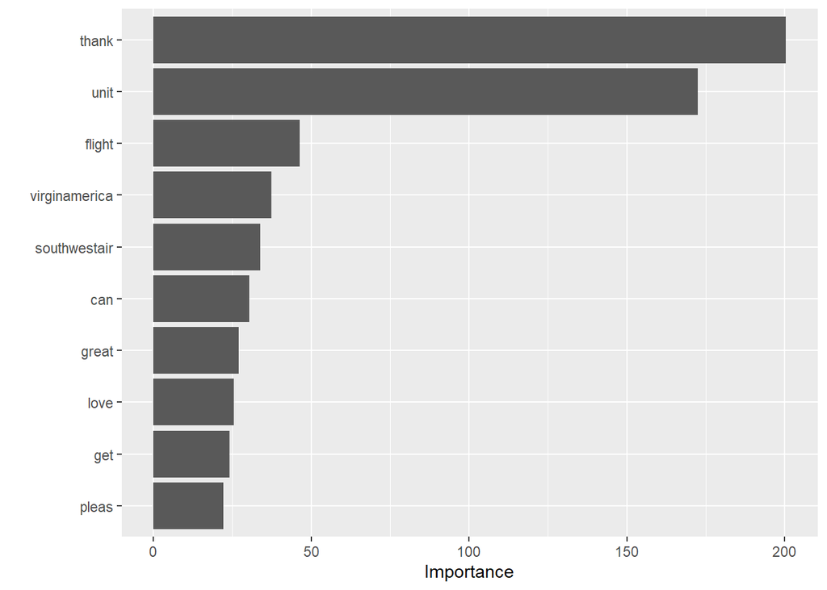

```r
#feature들의 중요도를 확인해보자
vip(bag1)
```

```r
bag1$importance
```

```
##                   MeanDecreaseGini
## X.jetblu                0.00000000
## abl                     2.43621486
## account                 1.90924029
## actual                  2.42206756
## add                     7.36298539
## agent                   3.55602795
## ago                     1.58685483
## air                     5.83010197
## airlin                 17.83588872
## airport                 7.06489330
## airway                  1.70698185
## allow                   3.38450932
## almost                  0.96583983
## alreadi                 4.07512543
## also                    4.46402110
## alway                   3.62180920
## amaz                   16.69595821
## american                0.09456762
## americanair             2.48195271
## amp                     5.86378698
## anoth                   3.76559685
## answer                  0.71697208
## anyon                   1.12208278
## anyth                   1.13072225
## apolog                  0.99214918
## app                     4.75259657
## appreci                 9.07411069
## arriv                   4.42657225
## ask                     5.49306299
## assist                  2.09160906
## attend                  4.73886591
## avail                   4.95590306
## away                    1.11043793
## awesom                 12.74790608
## back                    8.72046601
## bad                     1.44511141
## bag                    14.65884407
## baggag                  7.14295124
## best                    9.77693375
```

[output cut: 276 more lines]

```
## weather                 4.33596727
## websit                  7.10675289
## week                    4.08686742
## well                    5.53774087
## wife                    0.86828027
## wifi                    4.46722065
## will                   16.88520803
## without                 1.24248170
## work                    9.22731819
## worst                   3.23776585
## wrong                   1.39618153
## year                    9.25696929
## yes                    11.55269123
## yesterday               1.93361372
## yet                     1.57229799
```

```r
#bagging 모델의 test(valid) set에 대한 class 예측
pred_bag1 <- predict(bag1, newdata = testI, type="class")
#위 결과를 confusionMatrix로 확인
confusionMatrix(factor(pred_bag1),testI$sentiment)
```

```
## Confusion Matrix and Statistics
##
##           Reference
## Prediction negative neutral positive
##   negative      533     103       53
##   neutral        62      83       30
##   positive       30      25       79
##
## Overall Statistics
##
##                Accuracy : 0.6964
##                  95% CI : (0.6668, 0.7248)
##     No Information Rate : 0.6263
##     P-Value [Acc > NIR] : 1.999e-06
##
##                   Kappa : 0.4033
##
##  Mcnemar's Test P-Value : 0.0007014
##
## Statistics by Class:
##
##                      Class: negative Class: neutral Class: positive
## Sensitivity                   0.8528        0.39336         0.48765
## Specificity                   0.5818        0.88310         0.93421
## Pos Pred Value                0.7736        0.47429         0.58955
## Neg Pred Value                0.7023        0.84447         0.90394
## Prevalence                    0.6263        0.21142         0.16232
## Detection Rate                0.5341        0.08317         0.07916
## Detection Prevalence          0.6904        0.17535         0.13427
## Balanced Accuracy             0.7173        0.63823         0.71093
```

```r
#RandomForest========================================================
#DTM 사용
#randomForest는 Cross Validation 적용 시 너무 오래 걸리기 때문에 out-of-bag error를 최소화하는 mtry값을 찾아보자.

#1~50까지 mtry값에 대해 random forest 생성하고 error rate를 저장한다.
oob <- vector()
for(i in seq(1,50,2)){
        set.seed(123)
        rf <- randomForest(sentiment~., data=trainD, ntree= 50, mtry=i )
        oob <- c(oob, rf$err.rate[50,1])
}

#error rate가 가장 작을 때의 mtry 값을 찾는다.
which.min(oob)
```

```
## OOB
##   5
```

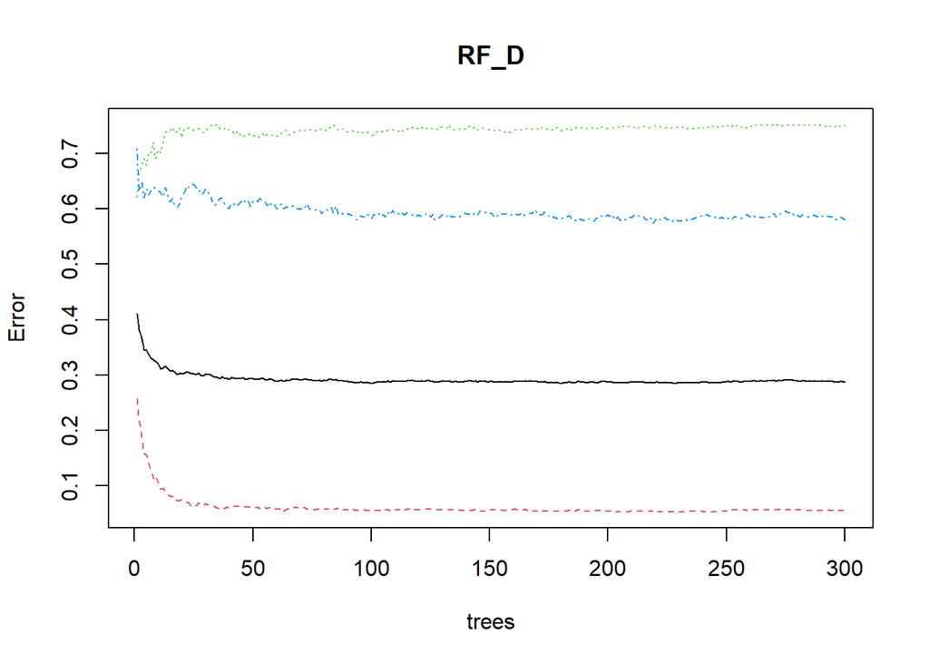

```r
#randomForest함수를 이용해 randomForest model 만들자. 앞에서 찾은 mtry값을 사용한다.
set.seed(123)
RF_D <- randomForest(sentiment~., data=trainD, mtry=5, ntree=300)

#시각화
plot(RF_D)
```

```r
RF_D
```

```
##
## Call:
##  randomForest(formula = sentiment ~ ., data = trainD, mtry = 5,      ntree = 300)
##                Type of random forest: classification
##                      Number of trees: 300
## No. of variables tried at each split: 5
##
##         OOB estimate of  error rate: 28.69%
## Confusion matrix:
##          negative neutral positive class.error
## negative     2369      89       47  0.05429142
## neutral       572     212       62  0.74940898
## positive      279      99      273  0.58064516
```

```r
#randomForest의 out-of bag prediction과 error rate
head(RF_D$predicted)
```

```
##        1        2        3        4        5        6
##  neutral  neutral  neutral  neutral  neutral negative
## Levels: negative neutral positive
```

```r
head(RF_D$err.rate)
```

```
##            OOB  negative   neutral  positive
## [1,] 0.4100863 0.2577540 0.6219512 0.7090164
## [2,] 0.3824847 0.2216428 0.6647510 0.6315789
## [3,] 0.3654990 0.1859110 0.6759690 0.6470588
## [4,] 0.3461313 0.1593458 0.6911357 0.6200000
## [5,] 0.3442849 0.1553398 0.6783854 0.6360544
## [6,] 0.3370667 0.1396934 0.6996245 0.6252073
```